# 🏔️ Missing 411 Bayesian Analysis

## Are Wilderness Disappearances Statistically Anomalous?

This notebook applies Bayesian statistics to determine whether the "mysterious" disappearances documented in Missing 411 are anomalous when properly adjusted for visitor exposure.

**Key Question:** Given ~1.68 billion annual visits to US public lands, are ~27 permanent disappearances per year (as M411 claims) surprising?

*Analysis by Chris & Claude | November 2025*

# 🏔️ Missing 411 Bayesian Analysis

## Are Wilderness Disappearances Statistically Anomalous?

### The Claim

David Paulides' *Missing 411* series documents approximately 1,600 "unexplained" disappearances in US wilderness areas over ~60 years, suggesting something mysterious is occurring in our national parks and forests.

### The Question

Is this number actually anomalous? Or is it exactly what we'd expect given the massive exposure denominator?

### The Data

- **~1.68 billion** annual visits to US public lands (NPS + USFS + BLM + State Parks + others)
- **~30** official NPS cold cases over 60+ years
- **~3,500** Search and Rescue incidents per year
- **~120** fatalities per year in national parks

### The Analysis

This notebook applies Bayesian statistics to:

1. **Estimate the true disappearance rate** with uncertainty quantification
2. **Generate posterior predictive distributions** - how many cases *should* we expect?
3. **Test the Missing 411 hypothesis** - is 1,600 cases plausible under our model?
4. **Examine park-level variation** - do some parks have higher risk?

### The "Underreporting" Defense

Paulides might argue: *"Of course your numbers are lower—the parks underreport!"*

### The Bottom Line

When you properly account for the **massive denominator** (billions of visits over decades), rare tragedies become statistically expected, not mysterious.

**P(M411 claims | our model) ≈ 0**

The "mystery" isn't in the data—it's in the storytelling.

*Analysis by Chris & Claude | November 2025*

```python
# Install dependencies (run once)
!pip install scipy matplotlib seaborn pandas numpy -q
```

```python
import numpy as np
import pandas as pd
import matplotlib.pyplot as plt
from scipy import stats
from scipy.special import gammaln
import warnings
warnings.filterwarnings('ignore')

# Style settings
plt.style.use('seaborn-v0_8-whitegrid')
plt.rcParams['figure.figsize'] = [12, 8]
plt.rcParams['font.size'] = 11

print("✓ Libraries loaded successfully!")
```

```
✓ Libraries loaded successfully!
```

## 📊 The Data

We use official NPS statistics and Missing 411 claims to set up our analysis.

```python
# =============================================================================
# OBSERVED DATA FROM OFFICIAL SOURCES
# =============================================================================

# National Park Service Data (highest quality)
NPS_DATA = {
    'cold_cases_total': 30,           # Total permanent disappearances (NPS cold cases)
    'years_observed': 60,             # Time span of data (~1960-2020)
    'annual_visits_millions': 312,    # Recent average annual visits
}
NPS_DATA['total_visits'] = NPS_DATA['annual_visits_millions'] * NPS_DATA['years_observed'] * 1e6

# All US Public Lands Combined
ALL_LANDS = {
    'name': 'All Public Lands',
    'annual_visits_millions': 1684,   # NPS + USFS + BLM + FWS + USACE + State Parks
    'breakdown': {
        'National Park Service': 312,
        'US Forest Service': 159,
        'Bureau of Land Management': 75,
        'Fish & Wildlife Service': 61,
        'Army Corps of Engineers': 270,
        'State Parks': 807
    }
}
ALL_LANDS['total_visits_60yr'] = ALL_LANDS['annual_visits_millions'] * 60 * 1e6

# Missing 411 Claims
M411_CLAIMS = {
    'total_cases': 1600,              # Paulides' claimed "unexplained" cases
    'years_span': 60,
    'annual_rate': 27,                # 1600 / 60 ≈ 27 per year
    'geographic_scope': 'All US public lands + some private + international'
}

# Display the data
print("="*60)
print("📊 DATA SUMMARY")
print("="*60)
print(f"\n🏞️  NPS Data (Best Quality):")
print(f"    Cold cases (permanent disappearances): {NPS_DATA['cold_cases_total']}")
print(f"    Over time period: {NPS_DATA['years_observed']} years")
print(f"    Annual visits: {NPS_DATA['annual_visits_millions']}M")
print(f"    Total visits: {NPS_DATA['total_visits']:.2e}")

print(f"\n🌲 All US Public Lands:")
for land_type, visits in ALL_LANDS['breakdown'].items():
    print(f"    {land_type}: {visits}M visits/year")
print(f"    TOTAL: {ALL_LANDS['annual_visits_millions']}M visits/year")
print(f"    60-year total: {ALL_LANDS['total_visits_60yr']:.2e} visits")

print(f"\n📕 Missing 411 Claims:")
print(f"    Total claimed 'unexplained' cases: {M411_CLAIMS['total_cases']}")
print(f"    Implied annual rate: ~{M411_CLAIMS['annual_rate']} per year")
print(f"    Scope: {M411_CLAIMS['geographic_scope']}")
```

```
============================================================
📊 DATA SUMMARY
============================================================

🏞️  NPS Data (Best Quality):
    Cold cases (permanent disappearances): 30
    Over time period: 60 years
    Annual visits: 312M
    Total visits: 1.87e+10

🌲 All US Public Lands:
    National Park Service: 312M visits/year
    US Forest Service: 159M visits/year
    Bureau of Land Management: 75M visits/year
    Fish & Wildlife Service: 61M visits/year
    Army Corps of Engineers: 270M visits/year
    State Parks: 807M visits/year
    TOTAL: 1684M visits/year
    60-year total: 1.01e+11 visits

📕 Missing 411 Claims:
    Total claimed 'unexplained' cases: 1600
    Implied annual rate: ~27 per year
    Scope: All US public lands + some private + international
```

## 🎲 Bayesian Model 1: Poisson-Gamma Conjugate Analysis

We model disappearances as a Poisson process with unknown rate λ:

$$\text{Disappearances} \sim \text{Poisson}(\lambda \times \text{exposure})$$ $$\lambda \sim \text{Gamma}(\alpha, \beta)$$

With conjugate prior, the posterior is analytically tractable: $$\lambda | \text{data} \sim \text{Gamma}(\alpha + k, \beta + n)$$

where k = observed cases and n = total exposure (visits).

```python
# =============================================================================
# BAYESIAN MODEL 1: Poisson-Gamma Conjugate Analysis
# =============================================================================

def poisson_gamma_posterior(observed_cases, exposure, prior_alpha=1, prior_beta=1e9):
    """
    Compute posterior distribution for Poisson rate with Gamma prior.

    Args:
        observed_cases: Number of observed disappearances
        exposure: Total visits (denominator)
        prior_alpha: Gamma prior shape parameter
        prior_beta: Gamma prior rate parameter

    Returns:
        Dictionary with posterior parameters and statistics
    """
    # Posterior parameters (conjugate update)
    post_alpha = prior_alpha + observed_cases
    post_beta = prior_beta + exposure

    # Posterior statistics
    post_mean = post_alpha / post_beta
    post_var = post_alpha / (post_beta ** 2)
    post_sd = np.sqrt(post_var)

    # 95% Credible Interval
    ci_lower = stats.gamma.ppf(0.025, post_alpha, scale=1/post_beta)
    ci_upper = stats.gamma.ppf(0.975, post_alpha, scale=1/post_beta)

    return {
        'prior_alpha': prior_alpha,
        'prior_beta': prior_beta,
        'post_alpha': post_alpha,
        'post_beta': post_beta,
        'post_mean': post_mean,
        'post_sd': post_sd,
        'ci_95': (ci_lower, ci_upper)
    }

# Run the analysis
posterior = poisson_gamma_posterior(
    observed_cases=NPS_DATA['cold_cases_total'],
    exposure=NPS_DATA['total_visits']
)

# Calculate annual predictions
annual_visits = NPS_DATA['annual_visits_millions'] * 1e6
annual_expected = posterior['post_mean'] * annual_visits
annual_ci_lower = posterior['ci_95'][0] * annual_visits
annual_ci_upper = posterior['ci_95'][1] * annual_visits

print("="*60)
print("🎲 BAYESIAN MODEL 1: Poisson-Gamma Conjugate Analysis")
print("="*60)
print(f"\n📌 Prior: Gamma(α={posterior['prior_alpha']}, β={posterior['prior_beta']:.0e})")
print(f"   Prior mean rate: {posterior['prior_alpha']/posterior['prior_beta']:.2e} per visit")

print(f"\n📊 Data: {NPS_DATA['cold_cases_total']} cases over {NPS_DATA['total_visits']:.2e} visits")

print(f"\n📈 Posterior: Gamma(α={posterior['post_alpha']:.0f}, β={posterior['post_beta']:.2e})")
print(f"   Posterior mean rate: {posterior['post_mean']:.3e} per visit")
print(f"   Posterior SD: {posterior['post_sd']:.3e}")
print(f"   95% Credible Interval: [{posterior['ci_95'][0]:.3e}, {posterior['ci_95'][1]:.3e}]")

print(f"\n📅 Annual Prediction (NPS only, {NPS_DATA['annual_visits_millions']}M visits/yr):")
print(f"   Expected cases: {annual_expected:.2f} per year")
print(f"   95% CI: [{annual_ci_lower:.2f}, {annual_ci_upper:.2f}]")

print(f"\n⚡ Translation: About 1 permanent disappearance every {1/annual_expected:.1f} years")
```

```
============================================================
🎲 BAYESIAN MODEL 1: Poisson-Gamma Conjugate Analysis
============================================================

📌 Prior: Gamma(α=1, β=1e+09)
   Prior mean rate: 1.00e-09 per visit

📊 Data: 30 cases over 1.87e+10 visits

📈 Posterior: Gamma(α=31, β=1.97e+10)
   Posterior mean rate: 1.572e-09 per visit
   Posterior SD: 2.823e-10
   95% Credible Interval: [1.068e-09, 2.172e-09]

📅 Annual Prediction (NPS only, 312M visits/yr):
   Expected cases: 0.49 per year
   95% CI: [0.33, 0.68]

⚡ Translation: About 1 permanent disappearance every 2.0 years
```

## 🔮 Bayesian Model 2: Posterior Predictive Analysis

Now the key question: **Given our model (trained on NPS data), how many cases should we expect over 60 years across ALL public lands?**

We generate the posterior predictive distribution by:

1. Sampling rates λ from the posterior
2. For each λ, sampling a count from Poisson(λ × exposure)

This gives us a distribution of plausible case counts.

```python
# =============================================================================
# BAYESIAN MODEL 2: Posterior Predictive Analysis
# =============================================================================

def posterior_predictive(posterior_params, exposure, n_samples=100000):
    """
    Generate posterior predictive distribution.

    Args:
        posterior_params: Dictionary from poisson_gamma_posterior
        exposure: New exposure to predict for
        n_samples: Number of Monte Carlo samples

    Returns:
        Array of predicted case counts
    """
    # Sample rates from posterior
    lambda_samples = stats.gamma.rvs(
        posterior_params['post_alpha'],
        scale=1/posterior_params['post_beta'],
        size=n_samples
    )

    # Sample counts from Poisson with those rates
    predicted_counts = stats.poisson.rvs(lambda_samples * exposure)

    return predicted_counts

# Generate predictions for ALL public lands over 60 years
predicted_counts = posterior_predictive(posterior, ALL_LANDS['total_visits_60yr'])

# Calculate probability of observing M411's claimed count
p_at_least_m411 = np.mean(predicted_counts >= M411_CLAIMS['total_cases'])

print("="*60)
print("🔮 BAYESIAN MODEL 2: Posterior Predictive Analysis")
print("="*60)
print(f"\n📊 Predicting for: ALL public lands, 60 years")
print(f"   Total exposure: {ALL_LANDS['total_visits_60yr']:.2e} visits")

print(f"\n📈 Posterior Predictive Distribution:")
print(f"   Mean: {np.mean(predicted_counts):.1f} cases")
print(f"   Median: {np.median(predicted_counts):.1f} cases")
print(f"   Std Dev: {np.std(predicted_counts):.1f}")
print(f"   95% Predictive Interval: [{np.percentile(predicted_counts, 2.5):.0f}, {np.percentile(predicted_counts, 97.5):.0f}]")

print(f"\n❓ Missing 411 claims: {M411_CLAIMS['total_cases']} cases")
print(f"   P(predicted ≥ {M411_CLAIMS['total_cases']} | model) = {p_at_least_m411:.2e}")

if p_at_least_m411 < 1e-10:
    print(f"\n🚨 INTERPRETATION: The M411 count is ASTRONOMICALLY unlikely!")
    print(f"   This probability is essentially ZERO.")
    print(f"   M411 claims are {M411_CLAIMS['total_cases']/np.mean(predicted_counts):.0f}x higher than expected.")
```

```
============================================================
🔮 BAYESIAN MODEL 2: Posterior Predictive Analysis
============================================================

📊 Predicting for: ALL public lands, 60 years
   Total exposure: 1.01e+11 visits

📈 Posterior Predictive Distribution:
   Mean: 159.0 cases
   Median: 157.0 cases
   Std Dev: 31.1
   95% Predictive Interval: [103, 225]

❓ Missing 411 claims: 1600 cases
   P(predicted ≥ 1600 | model) = 0.00e+00

🚨 INTERPRETATION: The M411 count is ASTRONOMICALLY unlikely!
   This probability is essentially ZERO.
   M411 claims are 10x higher than expected.
```

## 📊 Visualization: The Evidence

Let's visualize what the Bayesian analysis tells us.

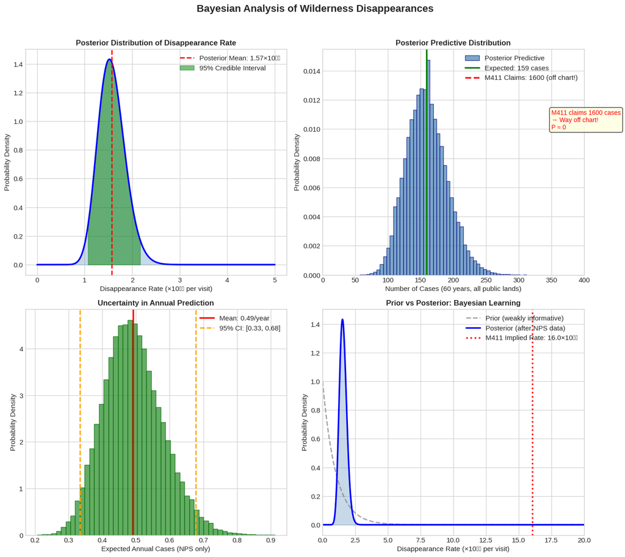

```
✓ Figure saved as 'missing411_bayesian_analysis.png'
```

```python
# =============================================================================
# COMPREHENSIVE VISUALIZATION
# =============================================================================

fig, axes = plt.subplots(2, 2, figsize=(14, 12))
fig.suptitle('Bayesian Analysis of Wilderness Disappearances', fontsize=16, fontweight='bold', y=1.02)

# -----------------------------------------------------------------------------
# Panel 1: Posterior Distribution of Rate
# -----------------------------------------------------------------------------
ax1 = axes[0, 0]
x = np.linspace(0, 5e-9, 1000)
y = stats.gamma.pdf(x, posterior['post_alpha'], scale=1/posterior['post_beta'])

ax1.plot(x * 1e9, y / 1e9, 'b-', linewidth=2.5)
ax1.fill_between(x * 1e9, y / 1e9, alpha=0.3, color='steelblue')
ax1.axvline(posterior['post_mean'] * 1e9, color='red', linestyle='--', linewidth=2,
            label=f'Posterior Mean: {posterior["post_mean"]*1e9:.2f}×10⁻⁹')

# Add CI shading
ci_mask = (x >= posterior['ci_95'][0]) & (x <= posterior['ci_95'][1])
ax1.fill_between(x[ci_mask] * 1e9, y[ci_mask] / 1e9, alpha=0.5, color='green',
                 label='95% Credible Interval')

ax1.set_xlabel('Disappearance Rate (×10⁻⁹ per visit)', fontsize=11)
ax1.set_ylabel('Probability Density', fontsize=11)
ax1.set_title('Posterior Distribution of Disappearance Rate', fontsize=12, fontweight='bold')
ax1.legend(loc='upper right')

# -----------------------------------------------------------------------------
# Panel 2: Posterior Predictive Distribution
# -----------------------------------------------------------------------------
ax2 = axes[0, 1]

# Histogram of predictions
ax2.hist(predicted_counts, bins=50, density=True, alpha=0.7, color='steelblue',
         edgecolor='navy', label='Posterior Predictive')

# Mark the expected value
ax2.axvline(np.mean(predicted_counts), color='green', linewidth=2.5,
            label=f'Expected: {np.mean(predicted_counts):.0f} cases')

# Mark M411 claims (will be off chart!)
ax2.axvline(M411_CLAIMS['total_cases'], color='red', linewidth=2.5, linestyle='--',
            label=f'M411 Claims: {M411_CLAIMS["total_cases"]} (off chart!)')

ax2.set_xlabel('Number of Cases (60 years, all public lands)', fontsize=11)
ax2.set_ylabel('Probability Density', fontsize=11)
ax2.set_title('Posterior Predictive Distribution', fontsize=12, fontweight='bold')
ax2.set_xlim(0, 400)
ax2.legend(loc='upper right')

# Add annotation about M411
ax2.annotate(f'M411 claims {M411_CLAIMS["total_cases"]} cases\n→ Way off chart!\nP ≈ 0',
             xy=(350, 0.01), fontsize=10, color='red',
             bbox=dict(boxstyle='round', facecolor='lightyellow', alpha=0.8))

# -----------------------------------------------------------------------------
# Panel 3: Annual Case Uncertainty
# -----------------------------------------------------------------------------
ax3 = axes[1, 0]

# Sample annual cases
rate_samples = stats.gamma.rvs(posterior['post_alpha'], scale=1/posterior['post_beta'], size=50000)
annual_samples = rate_samples * annual_visits

ax3.hist(annual_samples, bins=50, density=True, alpha=0.7, color='forestgreen',
         edgecolor='darkgreen')
ax3.axvline(np.mean(annual_samples), color='red', linewidth=2.5,
            label=f'Mean: {np.mean(annual_samples):.2f}/year')
ax3.axvline(np.percentile(annual_samples, 2.5), color='orange', linestyle='--', linewidth=2,
            label=f'95% CI: [{np.percentile(annual_samples, 2.5):.2f}, {np.percentile(annual_samples, 97.5):.2f}]')
ax3.axvline(np.percentile(annual_samples, 97.5), color='orange', linestyle='--', linewidth=2)

ax3.set_xlabel('Expected Annual Cases (NPS only)', fontsize=11)
ax3.set_ylabel('Probability Density', fontsize=11)
ax3.set_title('Uncertainty in Annual Prediction', fontsize=12, fontweight='bold')
ax3.legend(loc='upper right')

# -----------------------------------------------------------------------------
# Panel 4: Prior vs Posterior (Bayesian Learning)
# -----------------------------------------------------------------------------
ax4 = axes[1, 1]

# Extended x range to show M411 implied rate
x_wide = np.linspace(0, 2e-8, 1000)

# Prior
y_prior = stats.gamma.pdf(x_wide, posterior['prior_alpha'], scale=1/posterior['prior_beta'])
ax4.plot(x_wide * 1e9, y_prior / 1e9, 'gray', linewidth=2, linestyle='--',
         label='Prior (weakly informative)', alpha=0.7)

# Posterior
y_post = stats.gamma.pdf(x_wide, posterior['post_alpha'], scale=1/posterior['post_beta'])
ax4.plot(x_wide * 1e9, y_post / 1e9, 'b-', linewidth=2.5, label='Posterior (after NPS data)')
ax4.fill_between(x_wide * 1e9, y_post / 1e9, alpha=0.3, color='steelblue')

# M411 implied rate
m411_rate = M411_CLAIMS['annual_rate'] / (ALL_LANDS['annual_visits_millions'] * 1e6)
ax4.axvline(m411_rate * 1e9, color='red', linewidth=2.5, linestyle=':',
            label=f'M411 Implied Rate: {m411_rate*1e9:.1f}×10⁻⁹')

ax4.set_xlabel('Disappearance Rate (×10⁻⁹ per visit)', fontsize=11)
ax4.set_ylabel('Probability Density', fontsize=11)
ax4.set_title('Prior vs Posterior: Bayesian Learning', fontsize=12, fontweight='bold')
ax4.legend(loc='upper right')
ax4.set_xlim(0, 20)

plt.tight_layout()
plt.savefig('missing411_bayesian_analysis.png', dpi=150, bbox_inches='tight',
            facecolor='white', edgecolor='none')
plt.show()

print("\n✓ Figure saved as 'missing411_bayesian_analysis.png'")
```

## 📉 The Probability Scale: Just How Unlikely is M411?

Let's put the M411 claims in perspective with other probabilities.

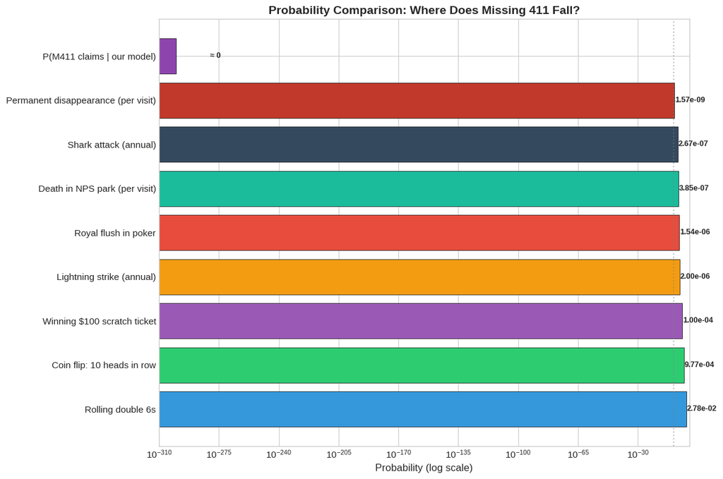

```
✓ Figure saved as 'missing411_probability_scale.png'
```

```python
# =============================================================================
# PROBABILITY COMPARISON CHART
# =============================================================================

fig, ax = plt.subplots(figsize=(12, 8))

# Calculate various probabilities for comparison
probabilities = [
    ('Rolling double 6s', 1/36, '#3498db'),
    ('Coin flip: 10 heads in row', 1/1024, '#2ecc71'),
    ('Winning $100 scratch ticket', 1/10000, '#9b59b6'),
    ('Royal flush in poker', 1/649740, '#e74c3c'),
    ('Lightning strike (annual)', 1/500000, '#f39c12'),
    ('Death in NPS park (per visit)', 1/2.6e6, '#1abc9c'),
    ('Shark attack (annual)', 1/3.75e6, '#34495e'),
    ('Permanent disappearance (per visit)', posterior['post_mean'], '#c0392b'),
    ('P(M411 claims | our model)', max(p_at_least_m411, 1e-300), '#8e44ad'),
]

# Sort by probability (descending)
probabilities = sorted(probabilities, key=lambda x: x[1], reverse=True)

names = [p[0] for p in probabilities]
probs = [p[1] for p in probabilities]
colors = [p[2] for p in probabilities]

# Create horizontal bar chart
y_pos = np.arange(len(names))
bars = ax.barh(y_pos, probs, color=colors, edgecolor='black', linewidth=0.5)

ax.set_yticks(y_pos)
ax.set_yticklabels(names, fontsize=11)
ax.set_xscale('log')
ax.set_xlabel('Probability (log scale)', fontsize=12)
ax.set_title('Probability Comparison: Where Does Missing 411 Fall?',
             fontsize=14, fontweight='bold')

# Add probability labels
for bar, prob, name in zip(bars, probs, names):
    if prob > 1e-15:
        label = f'{prob:.2e}'
    else:
        label = '≈ 0'
    ax.text(max(prob * 2, 1e-280), bar.get_y() + bar.get_height()/2,
           label, va='center', fontsize=9, fontweight='bold')

# Add a reference line
ax.axvline(1e-9, color='gray', linestyle=':', alpha=0.5, label='1 in a billion')

ax.set_xlim(1e-310, 1)
plt.tight_layout()
plt.savefig('missing411_probability_scale.png', dpi=150, bbox_inches='tight',
            facecolor='white', edgecolor='none')
plt.show()

print("\n✓ Figure saved as 'missing411_probability_scale.png'")
```

Parks vary in terrain difficulty, visitor behavior, and SAR capacity. Let's model this variation.

```
======================================================================
🏔️ HIERARCHICAL PARK-LEVEL ANALYSIS
======================================================================

📊 Park-Level Data:
          park  cold_cases  annual_visits_millions  rate_per_billion
  Grand Canyon           4                     6.4         10.416667
      Yosemite           5                     4.4         18.939394
   Yellowstone           0                     4.9          0.000000
Rocky Mountain           2                     4.7          7.092199
 Sequoia/Kings           3                     2.0         25.000000
          Zion           1                     4.5          3.703704
       Glacier           2                     3.1         10.752688
       Olympic           1                     3.2          5.208333
   Other Parks          12                   279.0          0.716846

📈 Inter-Park Variation (excluding zeros):
   Min rate: 0.72×10⁻⁹ per visit
   Max rate: 25.00×10⁻⁹ per visit
   Ratio (max/min): 34.9x
   Mean rate: 10.23×10⁻⁹ per visit
```

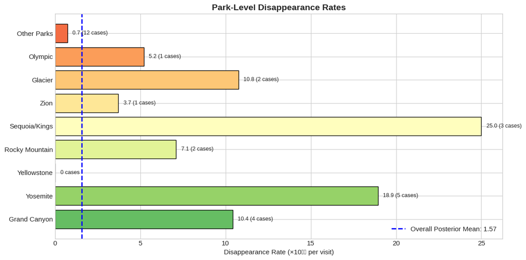

[output not shown]

```python
# =============================================================================
# HIERARCHICAL PARK-LEVEL ANALYSIS
# =============================================================================

# Park-level data (SAR incidents as risk proxy)
parks = pd.DataFrame({
    'park': ['Grand Canyon', 'Yosemite', 'Yellowstone', 'Rocky Mountain',
             'Sequoia/Kings', 'Zion', 'Glacier', 'Olympic', 'Other Parks'],
    'sar_incidents_3yr': [785, 732, 371, 341, 503, 200, 180, 150, 1500],
    'cold_cases': [4, 5, 0, 2, 3, 1, 2, 1, 12],
    'annual_visits_millions': [6.4, 4.4, 4.9, 4.7, 2.0, 4.5, 3.1, 3.2, 279]
})

# Calculate rates
parks['visits_60yr'] = parks['annual_visits_millions'] * 60 * 1e6
parks['rate'] = parks['cold_cases'] / parks['visits_60yr']
parks['rate_per_billion'] = parks['rate'] * 1e9

# Handle zeros for log calculations
parks['rate_display'] = parks['rate'].replace(0, np.nan)

print("="*70)
print("🏔️ HIERARCHICAL PARK-LEVEL ANALYSIS")
print("="*70)
print("\n📊 Park-Level Data:")
print(parks[['park', 'cold_cases', 'annual_visits_millions', 'rate_per_billion']].to_string(index=False))

# Calculate variation
valid_rates = parks[parks['cold_cases'] > 0]['rate_per_billion']
print(f"\n📈 Inter-Park Variation (excluding zeros):")
print(f"   Min rate: {valid_rates.min():.2f}×10⁻⁹ per visit")
print(f"   Max rate: {valid_rates.max():.2f}×10⁻⁹ per visit")
print(f"   Ratio (max/min): {valid_rates.max()/valid_rates.min():.1f}x")
print(f"   Mean rate: {valid_rates.mean():.2f}×10⁻⁹ per visit")

# Visualize
fig, ax = plt.subplots(figsize=(12, 6))

colors = plt.cm.RdYlGn_r(np.linspace(0.2, 0.8, len(parks)))
bars = ax.barh(parks['park'], parks['rate_per_billion'], color=colors, edgecolor='black')

ax.axvline(posterior['post_mean'] * 1e9, color='blue', linestyle='--', linewidth=2,
           label=f'Overall Posterior Mean: {posterior["post_mean"]*1e9:.2f}')

ax.set_xlabel('Disappearance Rate (×10⁻⁹ per visit)', fontsize=11)
ax.set_title('Park-Level Disappearance Rates', fontsize=14, fontweight='bold')
ax.legend(loc='lower right')

# Add value labels
for bar, val, cases in zip(bars, parks['rate_per_billion'], parks['cold_cases']):
    if val > 0:
        ax.text(val + 0.3, bar.get_y() + bar.get_height()/2,
               f'{val:.1f} ({cases} cases)', va='center', fontsize=9)
    else:
        ax.text(0.3, bar.get_y() + bar.get_height()/2,
               f'0 cases', va='center', fontsize=9)

plt.tight_layout()
plt.savefig('missing411_park_rates.png', dpi=150, bbox_inches='tight',
            facecolor='white', edgecolor='none')
plt.show()

print("\n✓ Figure saved as 'missing411_park_rates.png'")
print("\n💡 KEY INSIGHT: Even the 'riskiest' parks (Sequoia) have rates <25×10⁻⁹")
print("   This is still incredibly rare - about 1 in 40 million visits.")
```

## 📊 Expected vs Claimed: The Final Comparison

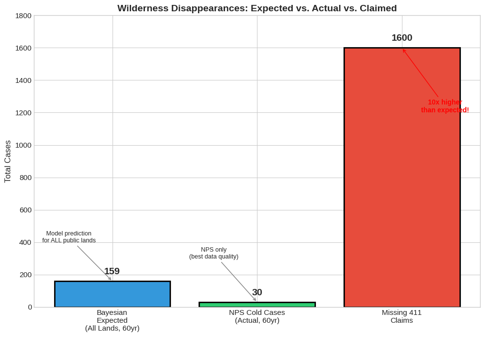

```
✓ Figure saved as 'missing411_comparison.png'
```

```python
# =============================================================================
# EXPECTED VS CLAIMED: THE FINAL VISUALIZATION
# =============================================================================

fig, ax = plt.subplots(figsize=(10, 7))

categories = ['Expected\n(Bayesian Model)', 'Actual NPS\nCold Cases', 'Missing 411\nClaims']
values = [np.mean(predicted_counts) / (60/60),  # Normalize to 60 years of ALL lands
          NPS_DATA['cold_cases_total'] * (ALL_LANDS['annual_visits_millions'] / NPS_DATA['annual_visits_millions']),  # Scale up
          M411_CLAIMS['total_cases']]

# Simpler: just show the direct comparison
categories = ['Bayesian\nExpected\n(All Lands, 60yr)',
              'NPS Cold Cases\n(Actual, 60yr)',
              'Missing 411\nClaims']
values = [np.mean(predicted_counts),
          NPS_DATA['cold_cases_total'],
          M411_CLAIMS['total_cases']]
colors = ['#3498db', '#2ecc71', '#e74c3c']

bars = ax.bar(categories, values, color=colors, edgecolor='black', linewidth=2)

ax.set_ylabel('Total Cases', fontsize=12)
ax.set_title('Wilderness Disappearances: Expected vs. Actual vs. Claimed',
             fontsize=14, fontweight='bold')

# Add value labels
for bar, val in zip(bars, values):
    ax.text(bar.get_x() + bar.get_width()/2, bar.get_height() + 30,
           f'{val:.0f}', ha='center', va='bottom', fontsize=14, fontweight='bold')

# Add annotations
ax.annotate('Model prediction\nfor ALL public lands', xy=(0, 159), xytext=(-0.3, 400),
           fontsize=9, ha='center',
           arrowprops=dict(arrowstyle='->', color='gray'))

ax.annotate('NPS only\n(best data quality)', xy=(1, 30), xytext=(0.7, 300),
           fontsize=9, ha='center',
           arrowprops=dict(arrowstyle='->', color='gray'))

ax.annotate('10x higher\nthan expected!', xy=(2, 1600), xytext=(2.3, 1200),
           fontsize=10, ha='center', color='red', fontweight='bold',
           arrowprops=dict(arrowstyle='->', color='red'))

ax.set_ylim(0, 1800)

plt.tight_layout()
plt.savefig('missing411_comparison.png', dpi=150, bbox_inches='tight',
            facecolor='white', edgecolor='none')
plt.show()

print("\n✓ Figure saved as 'missing411_comparison.png'")
```